# RNA-seq: Raw FASTQ to Read Counts Tutorial

Nikita Telkar

British Columbia Children’s Hospital Research Institute, Vancouver, Canada  
British Columbia Cancer Research Centre, Vancouver, Canada

September 2022

**This tutorial walks through how to get a final gene expression matrix/data frame that contains the raw read/expression counts from raw RNA sequencing data**

Raw RNA sequencing data is stored in files formatted with the suffix `.FASTQ`

If you used the `head` command in terminal followed by the name of your FASTQ file, you’ll get an output that looks something like the below:

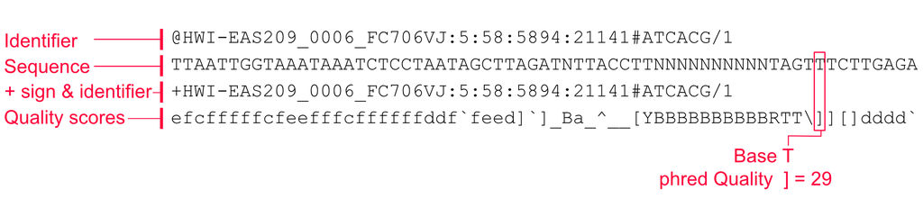

from https://compgenomr.github.io/book/fasta-and-fastq-formats.html

> I’m going to use the low-input miRNA-specific primer/adapters used for the sequencing of my project samples as an example

The construct for my sequences look like:

5’ HHHHHHHHCA-`miRNA`–*TGGAATTCTCGGGTGCCAAG***TCGACGTACGATCNNNNNNATCTCGTATGCCGTCTTCTGCTTG** 3’

1. UMI - 8pb HHHHHHHH
2. CA dinucleotide
3. `miRNA sequence: 17-25bp`
4. *Index Primer - 20 nt*
5. **Adapter - Variable length, depending upon the length of the miRNA**

## 1.0 Run sequence data through FASTQC

Check that:

1. Phred Scores are above 20 for *per base sequence quality* for bases 11-31/35 for untrimmed FASTQ files or for bases 1-21/25 for Adapter/UMI/index primer trimmed FASTQ files.
2. Nucleotide Content is distributed evenly for the the bases specified above
3. Adapter content not presetnt in trimmed files

## 2.0 Trim adapter + primers: via `cutadapt`

### 2.1 Activate [cutAdapt](https://cutadapt.readthedocs.io/en/stable/guide.html)

```bash
#create new env to run cutadapt
conda create --name cutadapt

#activate env
source activate cutadapt
```

### 2.2 Full Command

The below command uses all the required flags for trimming our UMI + adapter + index primer. To go through each flag on it’s own, scroll down to section 2.3 and section 2.4

```bash
#command explanation
cutadapt --cut No.of.nucleotides(positive_integer_for_from_start_of_seq) -a adapterEQUENCE -o output.fastq input.fastq

#for one file
cutadapt --cut 10 -a TGGAATTCTCGGGTGCCAAG --cores=8 -o trimmed_M20072_5_3_prime.fastq M20072_1_75bp_4_lanes.merge_chastity_passed.fastq.gz

#for multiple files
for file in *.fastq.gz; do cutadapt --cut 10 -a TGGAATTCTCGGGTGCCAAG --cores=8 -o trimmed/trimmed_Adapter_${file} ${file}; done

---


# NOTE: EMPTY SEQS WITH 0 LENGTH ARE KEPT BY DEFAULT. Read further on how to to trim by sequence length using Trimmomatic

This is cutadapt 1.18 with Python 3.7.11
Command line parameters: --cut 10 -a TGGAATTCTCGGGTGCCAAG --cores=8 -o trimmed_M20072_5_3_prime.fastq M20072_1_75bp_4_lanes.merge_chastity_passed.fastq.gz
Processing reads on 8 cores in single-end mode ...
Finished in 40.52 s (2 us/read; 25.62 M reads/minute).

=== Summary ===

Total reads processed:              17,299,822
Reads with adapters:                16,894,173 (97.7%)
Reads written (passing filters):    17,299,822 (100.0%)

Total basepairs processed: 1,297,486,650 bp
Total written (filtered):    294,338,511 bp (22.7%)

=== Adapter 1 ===

Sequence: TGGAATTCTCGGGTGCCAAG; Type: regular 3'; Length: 20; Trimmed: 16894173 times.

No. of allowed errors:
0-9 bp: 0; 10-19 bp: 1; 20 bp: 2

Bases preceding removed adapters:
  A: 16.9%
  C: 26.4%
  G: 28.1%
  T: 28.4%
  none/other: 0.2%

Overview of removed sequences
length  count   expect  max.err error counts
3       6034    270309.7        0       6034
4       976     67577.4 0       976
5       346     16894.4 0       346
6       330     4223.6  0       330
7       286     1055.9  0       286
8       247     264.0   0       247
9       298     66.0    0       296 2
10      254     16.5    1       251 3
11      326     4.1     1       324 2
12      407     1.0     1       398 9
13      399     0.3     1       387 12
14      772     0.1     1       749 23
15      657     0.0     1       643 14
16      470     0.0     1       458 12
17      498     0.0     1       488 10
18      479     0.0     1       471 8
19      561     0.0     1       549 12
20      557     0.0     2       541 14 2
21      616     0.0     2       591 20 5
22      626     0.0     2       608 17 1
23      816     0.0     2       795 16 5
24      1041    0.0     2       1004 33 4
25      1347    0.0     2       1290 52 5
26      3270    0.0     2       3162 94 14
27      2979    0.0     2       2867 101 11
28      5654    0.0     2       5434 201 19
29      6189    0.0     2       5911 262 16
30      11515   0.0     2       11011 460 44
31      37047   0.0     2       35612 1322 113
32      138518  0.0     2       133276 4812 430
33      113793  0.0     2       109987 3492 314
34      72991   0.0     2       70515 2234 242
35      80063   0.0     2       77643 2195 225
36      92938   0.0     2       90166 2497 275
37      78619   0.0     2       76504 1912 203
38      110466  0.0     2       107676 2538 252
39      134998  0.0     2       131433 3204 361
40      187145  0.0     2       182800 3945 400
41      298337  0.0     2       291571 6102 664
42      649939  0.0     2       636035 12571 1333
43      1737975 0.0     2       1702490 32150 3335
44      1224792 0.0     2       1197647 24364 2781
45      668877  0.0     2       654460 13096 1321
46      557184  0.0     2       544664 11212 1308
47      602187  0.0     2       583364 17394 1429
48      711765  0.0     2       696215 14234 1316
49      696045  0.0     2       681673 13044 1328
50      846984  0.0     2       830436 15156 1392
51      882012  0.0     2       865943 14774 1295
52      938953  0.0     2       921372 16231 1350
53      981538  0.0     2       963091 16995 1452
54      993879  0.0     2       976048 16458 1373
55      956888  0.0     2       939507 16034 1347
56      837993  0.0     2       822973 13782 1238
57      784397  0.0     2       770982 12444 971
58      552835  0.0     2       543442 8716 677
59      430457  0.0     2       423434 6530 493
60      249946  0.0     2       245770 3911 265
61      102393  0.0     2       100699 1563 131
62      35366   0.0     2       34771 550 45
63      10156   0.0     2       9908 237 11
64      19054   0.0     2       18705 331 18
65      29693   0.0     2       21256 5255 3182
```

### 2.3 Removing 3’ Adapter

```bash
# to remove 3' varaible Adapter. Everything matching to the Adapter sequence and all bases after it will be removed (works
# perfectly where the 3' Adapter starts with a fixed 20nt index seq TGGAATTCTCGGGTGCCAAG, and contains a variable
# Adapter/primer lenght after)

cutadapt -a adapterEQUENCE -o output.fastq input.fastq

cutadapt -a TGGAATTCTCGGGTGCCAAG -o trimmed_M20072.fastq M20072_1_75bp_4_lanes.merge_chastity_passed.fastq.gz

This is cutadapt 1.18 with Python 3.7.11
Command line parameters: -a TGGAATTCTCGGGTGCCAAG -o trimmed_M20072.fastq M20072_1_75bp_4_lanes.merge_chastity_passed.fastq.gz
Processing reads on 1 core in single-end mode ...
Finished in 259.27 s (15 us/read; 4.00 M reads/minute).

=== Summary ===

  Total reads processed:              17,299,822
Reads with adapters:                16,980,740 (98.2%)
Reads written (passing filters):    17,299,822 (100.0%)

Total basepairs processed: 1,297,486,650 bp
Total written (filtered):    460,834,376 bp (35.5%)

=== Adapter 1 ===

  Sequence: TGGAATTCTCGGGTGCCAAG; Type: regular 3'; Length: 20; Trimmed: 16980740 times.

No. of allowed errors:
0-9 bp: 0; 10-19 bp: 1; 20 bp: 2

Bases preceding removed adapters:
  A: 17.1%
  C: 26.5%
  G: 28.0%
  T: 28.3%
  none/other: 0.2%

Overview of removed sequences
length  count   expect  max.err error counts
3       4704    270309.7        0       4704
4       976     67577.4 0       976
5       346     16894.4 0       346
6       330     4223.6  0       330
7       286     1055.9  0       286
8       247     264.0   0       247
9       298     66.0    0       296 2
10      254     16.5    1       251 3
11      326     4.1     1       324 2
12      407     1.0     1       398 9
13      399     0.3     1       387 12
14      772     0.1     1       749 23
15      657     0.0     1       643 14
16      470     0.0     1       458 12
17      498     0.0     1       488 10
18      479     0.0     1       471 8
19      561     0.0     1       549 12
20      557     0.0     2       541 14 2
21      616     0.0     2       591 20 5
22      626     0.0     2       608 17 1
23      816     0.0     2       795 16 5
24      1041    0.0     2       1004 33 4
25      1347    0.0     2       1290 52 5
26      3270    0.0     2       3162 94 14
27      2979    0.0     2       2867 101 11
28      5654    0.0     2       5434 201 19
29      6189    0.0     2       5911 262 16
30      11515   0.0     2       11011 460 44
31      37047   0.0     2       35612 1322 113
32      138518  0.0     2       133276 4812 430
33      113793  0.0     2       109987 3492 314
34      72991   0.0     2       70515 2234 242
35      80063   0.0     2       77643 2195 225
36      92938   0.0     2       90166 2497 275
37      78619   0.0     2       76504 1912 203
38      110466  0.0     2       107676 2538 252
39      134998  0.0     2       131433 3204 361
40      187145  0.0     2       182800 3945 400
41      298337  0.0     2       291571 6102 664
42      649939  0.0     2       636035 12571 1333
43      1737975 0.0     2       1702490 32150 3335
44      1224792 0.0     2       1197647 24364 2781
45      668877  0.0     2       654460 13096 1321
46      557184  0.0     2       544664 11212 1308
47      602186  0.0     2       583364 17394 1428
48      711765  0.0     2       696215 14234 1316
49      696045  0.0     2       681673 13044 1328
50      846984  0.0     2       830436 15156 1392
51      882012  0.0     2       865943 14774 1295
52      938953  0.0     2       921372 16231 1350
53      981538  0.0     2       963091 16995 1452
54      993879  0.0     2       976048 16458 1373
55      956888  0.0     2       939507 16034 1347
56      837993  0.0     2       822973 13782 1238
57      784397  0.0     2       770982 12444 971
58      552835  0.0     2       543442 8716 677
59      430457  0.0     2       423434 6530 493
60      249946  0.0     2       245770 3911 265
61      102393  0.0     2       100699 1563 131
62      35366   0.0     2       34771 550 45
63      10156   0.0     2       9908 237 11
64      19052   0.0     2       18705 331 16
65      21636   0.0     2       21256 352 28
66      4976    0.0     2       4869 95 12
67      3143    0.0     2       2441 672 30
68      2567    0.0     2       1591 943 33
69      2735    0.0     2       1801 883 51
70      819     0.0     2       492 316 11
71      2599    0.0     2       1408 1136 55
72      1685    0.0     2       510 175 1000
73      1718    0.0     2       165 101 1452
74      39261   0.0     2       92 247 38922
75      36454   0.0     2       87 635 35732
```

### 2.4 Removing 5’ Fixed Nucleotides

```bash
# to remove n no. of bases from the start of the read (e.g. for the 8bp UMI and 2 CA nt at the start of each read).

cutadapt -cut No.of.nucleotides -o output.fastq input.fastq

cutadapt --cut 10 -o trimmed_M20072_5prime.fastq M20072_1_75bp_4_lanes.merge_chastity_passed.fastq.gz



This is cutadapt 1.18 with Python 3.7.11
Command line parameters: --cut 10 -o trimmed_M20072_5prime.fastq M20072_1_75bp_4_lanes.merge_chastity_passed.fastq.gz
Processing reads on 1 core in single-end mode ...
Finished in 94.13 s (5 us/read; 11.03 M reads/minute).

=== Summary ===

Total reads processed:              17,299,822
Reads with adapters:                         0 (0.0%)
Reads written (passing filters):    17,299,822 (100.0%)

Total basepairs processed: 1,297,486,650 bp
Total written (filtered):  1,124,488,430 bp (86.7%)
```

### 2.5 Keeping Sequences with Mininum length of 17: Trimmomatic

This step is required because cutadapt retains empty sequences with 0 bases by default. Need to remove them before perfoming alignment either manually or by miRMaster.

```bash
source deactivate

#create new env to run trimmomatic
conda create --name trimmomatic

#activate env
source activate trimmomatic

#for one file
trimmomatic SE -threads 5 trimmed_M20072.fastq trimmomatic/M20072_trimmed_min17.fastq MINLEN:17

#for multiple files

for file in *.fastq.gz; do trimmomatic SE -threads 5 ${file} trimmomatic/trimmed_min17_${file} -trimlog log MINLEN:17; done
```

## 3.0 Raw FASTQ to Aligned BAM

Once you’ve processed and trimmed your FASTQ files, they’re nwo ready to be aligned to the genome

### 3.1 Download Reference genome

From [Encode](https://www.gencodegenes.org/human/), download the the latest version of the

- human reference genome build (.fasta / .fa)
- Optional but highly recommended: genome annotation file (.gtf)

**Make sure to download both the files from the same source, and do not mix and match (i.e., one from UCSC and one from ENCODE do not align)**

### 3.2 Install Miniconda

**1. Install Conda via miniconda**:

[Option 1](https://waylonwalker.com/install-miniconda/) / [Option 2](https://dev.to/waylonwalker/installing-miniconda-on-linux-from-the-command-line-4ad7)

**2. [Set up bioconda channels](http://bioconda.github.io/user/install.html#set-up-channels)**

**3. Make a new environment** to work in (let’s call this one snowflakes)

```bash
conda create --name snowflakes
```

**4. Activate your environment**

```bash
source activate snowflakes
```

**5. Install [`samtools`](http://www.sthda.com/english/wiki/install-samtools-on-unix-system)**

### 3.3 Sequence Alignment to Genome

> Alignment of sequences to the reference genome contains 2 steps:
1. Make an index of the genome (only need to perform this step once per genome-annotation pair file)
2. Align your sequences using the indexed genome

#### 3.3.1 Alignment using STAR

**1. Install STAR**

```bash
conda install -c bioconda star
STAR --help
```

**2. Check number of available threads**

```bash
lscpu
#multiply number of sockets by number of cores by number of threads
```

**3. Make directory to store index**

```bash
mkdir hg38_index_STAR
```

**4. Make index from genome using STAR**

```bash
STAR --runThreadN 10 --runMode genomeGenerate --genomeDir hg38_index_STAR --genomeFastaFiles GRCh38_latest_genomic.fna --sjdbGTFfile gencode.v38.annotation.gtf
```

–genomeDir = directory to store indexed files –genomeFastaFiles = reference genome fasta file –sjdbGTFfile = GTF annotation file –> optional, but useful

**5. Align trimmed fastq files**

The below are the most basic minimum commands you can use for alignment. Several detailed commands exist, whcih you can view in the [STAR manual here](https://physiology.med.cornell.edu/faculty/skrabanek/lab/angsd/lecture_notes/STARmanual.pdf)

```bash
mkdir mapped_files

STAR --runThreadN 30 --genomeDir hg38_index_STAR --readFilesIn trimmed_fastq_file.fastq --outFilterIntronMotifs RemoveNoncanonical --outFileNamePrefix mapped_files/mapped_ --outSAMtype BAM SortedByCoordinate
```

`--genomeDir` = directory where indexed files are stored –> different from above!  
`--readFilesIn` = trimmed fastq files  
`--outFilterIntronMotifs` RemoveNoncanonical = Removing any SNV variations  
`--outFileNamePrefix` = prefix to add to mapped files  
`--outSAMtype` BAM = SAM or BAM output file (here BAM and SortedByCoordinate)

> The output will be a sorted BAM file (from which you can generate expression counts in R using the `featureCounts` function from the `{Rsubread}` package, 3 log files displaying the detailed steps of processing and their output, and a SJ.out.tab file with any splice junctions)